# Lab 5: Recurrent Neural Networks

Author

Ben Kessler

Published

May 19, 2024

```
2024-05-19 10:47:58.830425: I tensorflow/core/platform/cpu_feature_guard.cc:210] This TensorFlow binary is optimized to use available CPU instructions in performance-critical operations.
To enable the following instructions: AVX2 FMA, in other operations, rebuild TensorFlow with the appropriate compiler flags.
```

## Data

For this lab we will be predicting the open price in USD.

```python
def create_dataset(dataset, look_back=1):
    X, y = [], []
    for i in range(len(dataset)-look_back-1):
        X.append(dataset[i:(i+look_back), 0])
        y.append(dataset[i + look_back, 0])
    return np.array(X), np.array(y)
```

```python
data = pd.read_csv("/Users/ben/Documents/GitHub/AdvancedMachineLearning/Data/BitcoinData/dc.csv")
data = data.iloc[::-1].reset_index(drop=True) # Reverse the order of the dataframe so that the newest dates are at the end of the dataset instead of the beginning
data = data[["open_USD"]]
data.head()
```

|  | open_USD |
| --- | --- |
| 0 | 9661.02 |
| 1 | 9365.00 |
| 2 | 9178.00 |
| 3 | 9310.00 |
| 4 | 9002.21 |

## RNN Model Set 1 - 80/20 Split, 1 Day Lookback

First we will start by preparing the dataset and splitting into training and testing sets. For this first set of models, we will begin with an 80/20 test training split and a 1 day lookback value. We will explore a simple RNN Model and a LSTM Model.

### Simple RNN Model

```python
scaler = MinMaxScaler(feature_range=(0, 1))
scaled_data = scaler.fit_transform(data)

# Train test split of 80/20
train_size = int(len(scaled_data) * .8)
test_size = len(scaled_data) - train_size
train, test = scaled_data[0:train_size], scaled_data[train_size:]
print(len(train), len(test))

# Reshape dataset to X = t and y = t+1
# Look back 1 day
look_back = 1
X_train, y_train = create_dataset(train, look_back)
X_test, y_test = create_dataset(test, look_back)
print(X_train.shape, X_test.shape)

X_train = np.reshape(X_train, (X_train.shape[0], 1, X_train.shape[1]))
X_test = np.reshape(X_test, (X_test.shape[0], 1, X_test.shape[1]))
print(X_train.shape, X_test.shape)
```

```
800 200
(798, 1) (198, 1)
(798, 1, 1) (198, 1, 1)
```

```python
# Simple RNN Network
model = Sequential()
model.add(SimpleRNN(8, input_shape = (1, look_back)))
model.add(Dense(1))
model.compile(loss="mean_squared_error", optimizer="adam", metrics=["mean_squared_error"])
model.fit(X_train, y_train, epochs = 100, batch_size = 1, verbose = 2)
```

```
798/798 - 2s - 3ms/step - loss: 0.0015 - mean_squared_error: 0.0015
798/798 - 1s - 993us/step - loss: 7.5321e-05 - mean_squared_error: 7.5321e-05
798/798 - 1s - 1ms/step - loss: 7.4875e-05 - mean_squared_error: 7.4875e-05
798/798 - 1s - 987us/step - loss: 7.8542e-05 - mean_squared_error: 7.8542e-05
798/798 - 1s - 997us/step - loss: 8.0134e-05 - mean_squared_error: 8.0134e-05
798/798 - 1s - 991us/step - loss: 7.9994e-05 - mean_squared_error: 7.9994e-05
798/798 - 1s - 987us/step - loss: 8.0956e-05 - mean_squared_error: 8.0956e-05
798/798 - 1s - 992us/step - loss: 8.5768e-05 - mean_squared_error: 8.5768e-05
798/798 - 1s - 988us/step - loss: 8.2320e-05 - mean_squared_error: 8.2320e-05
798/798 - 1s - 989us/step - loss: 7.7620e-05 - mean_squared_error: 7.7620e-05
798/798 - 1s - 995us/step - loss: 8.2691e-05 - mean_squared_error: 8.2691e-05
798/798 - 1s - 981us/step - loss: 8.2361e-05 - mean_squared_error: 8.2361e-05
798/798 - 1s - 985us/step - loss: 7.8693e-05 - mean_squared_error: 7.8693e-05
798/798 - 1s - 991us/step - loss: 7.6980e-05 - mean_squared_error: 7.6980e-05
798/798 - 1s - 990us/step - loss: 8.1368e-05 - mean_squared_error: 8.1368e-05
798/798 - 1s - 991us/step - loss: 8.2142e-05 - mean_squared_error: 8.2142e-05
798/798 - 1s - 994us/step - loss: 7.6199e-05 - mean_squared_error: 7.6199e-05
798/798 - 1s - 990us/step - loss: 7.7995e-05 - mean_squared_error: 7.7995e-05
798/798 - 1s - 987us/step - loss: 7.6380e-05 - mean_squared_error: 7.6380e-05
798/798 - 1s - 993us/step - loss: 7.7900e-05 - mean_squared_error: 7.7900e-05
798/798 - 1s - 994us/step - loss: 8.0378e-05 - mean_squared_error: 8.0378e-05
798/798 - 1s - 1ms/step - loss: 7.4804e-05 - mean_squared_error: 7.4804e-05
798/798 - 1s - 1ms/step - loss: 7.7129e-05 - mean_squared_error: 7.7129e-05
798/798 - 1s - 1ms/step - loss: 8.0314e-05 - mean_squared_error: 8.0314e-05
798/798 - 1s - 991us/step - loss: 7.4831e-05 - mean_squared_error: 7.4831e-05
798/798 - 1s - 992us/step - loss: 7.4614e-05 - mean_squared_error: 7.4614e-05
798/798 - 1s - 996us/step - loss: 8.0983e-05 - mean_squared_error: 8.0983e-05
798/798 - 1s - 991us/step - loss: 7.6975e-05 - mean_squared_error: 7.6975e-05
798/798 - 1s - 1ms/step - loss: 7.7138e-05 - mean_squared_error: 7.7138e-05
798/798 - 1s - 993us/step - loss: 7.5021e-05 - mean_squared_error: 7.5021e-05
798/798 - 1s - 991us/step - loss: 7.7249e-05 - mean_squared_error: 7.7249e-05
798/798 - 1s - 995us/step - loss: 7.5623e-05 - mean_squared_error: 7.5623e-05
798/798 - 1s - 997us/step - loss: 7.5230e-05 - mean_squared_error: 7.5230e-05
798/798 - 1s - 991us/step - loss: 7.7414e-05 - mean_squared_error: 7.7414e-05
798/798 - 1s - 991us/step - loss: 7.4426e-05 - mean_squared_error: 7.4426e-05
798/798 - 1s - 991us/step - loss: 7.8461e-05 - mean_squared_error: 7.8461e-05
798/798 - 1s - 990us/step - loss: 7.1494e-05 - mean_squared_error: 7.1494e-05
798/798 - 1s - 993us/step - loss: 7.5403e-05 - mean_squared_error: 7.5403e-05
798/798 - 1s - 990us/step - loss: 7.4936e-05 - mean_squared_error: 7.4936e-05
798/798 - 1s - 993us/step - loss: 7.3563e-05 - mean_squared_error: 7.3563e-05
```

[output cut: 45 more lines]

```
798/798 - 1s - 996us/step - loss: 6.8666e-05 - mean_squared_error: 6.8666e-05
798/798 - 1s - 987us/step - loss: 7.0573e-05 - mean_squared_error: 7.0573e-05
798/798 - 1s - 991us/step - loss: 7.5292e-05 - mean_squared_error: 7.5292e-05
798/798 - 1s - 989us/step - loss: 7.4446e-05 - mean_squared_error: 7.4446e-05
798/798 - 1s - 986us/step - loss: 7.2514e-05 - mean_squared_error: 7.2514e-05
798/798 - 1s - 985us/step - loss: 7.3760e-05 - mean_squared_error: 7.3760e-05
798/798 - 1s - 986us/step - loss: 7.3064e-05 - mean_squared_error: 7.3064e-05
798/798 - 1s - 993us/step - loss: 7.2164e-05 - mean_squared_error: 7.2164e-05
798/798 - 1s - 998us/step - loss: 7.5327e-05 - mean_squared_error: 7.5327e-05
798/798 - 1s - 994us/step - loss: 7.2804e-05 - mean_squared_error: 7.2804e-05
798/798 - 1s - 985us/step - loss: 7.2172e-05 - mean_squared_error: 7.2172e-05
798/798 - 1s - 985us/step - loss: 7.1335e-05 - mean_squared_error: 7.1335e-05
798/798 - 1s - 994us/step - loss: 7.4344e-05 - mean_squared_error: 7.4344e-05
798/798 - 1s - 994us/step - loss: 7.2854e-05 - mean_squared_error: 7.2854e-05
798/798 - 1s - 995us/step - loss: 7.3333e-05 - mean_squared_error: 7.3333e-05
```

```
<keras.src.callbacks.history.History at 0x175e07650>
```

```python
# Make predictions
y_pred_train = model.predict(X_train)
y_pred_test = model.predict(X_test)
# Unscale predictions
y_pred_train = scaler.inverse_transform(y_pred_train)
y_pred_test = scaler.inverse_transform(y_pred_test)
y_train = scaler.inverse_transform([y_train])
y_test = scaler.inverse_transform([y_test])
# Calculate RMSE
train_score = np.sqrt(mean_squared_error(y_train[0], y_pred_train[:,0]))
test_score = np.sqrt(mean_squared_error(y_test[0], y_pred_test[:, 0]))
print(f"Train RMSE: {train_score}")
print(f"Test RMSE: {test_score}")
```

```
25/25 ━━━━━━━━━━━━━━━━━━━━ 0s 6ms/step
7/7 ━━━━━━━━━━━━━━━━━━━━ 0s 1ms/step
Train RMSE: 307.2548790796108
Test RMSE: 2542.7869167567696
```

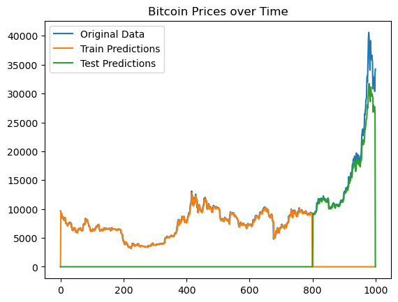

```python
train_predict_plot = np.empty_like(data)
train_predict_plot[:, :] = 0
train_predict_plot[look_back:len(y_pred_train)+look_back, :] = y_pred_train
test_predict_plot = np.empty_like(data)
test_predict_plot[:, :] = 0
test_predict_plot[len(y_pred_train)+(look_back*2)+1:len(data)-1, :] = y_pred_test

plt.plot(scaler.inverse_transform(scaled_data.copy()), label="Original Data")
plt.plot(train_predict_plot, label="Train Predictions")
plt.plot(test_predict_plot, label="Test Predictions")
plt.legend()
plt.title("Bitcoin Prices over Time")
plt.show()
```

### LSTM Model

```python
scaler = MinMaxScaler(feature_range=(0, 1))
scaled_data = scaler.fit_transform(data)

# Train test split of 80/20
train_size = int(len(scaled_data) * .8)
test_size = len(scaled_data) - train_size
train, test = scaled_data[0:train_size], scaled_data[train_size:]
print(len(train), len(test))

# Reshape dataset to X = t and y = t+1
# Look back 1 day
look_back = 1
X_train, y_train = create_dataset(train, look_back)
X_test, y_test = create_dataset(test, look_back)
print(X_train.shape, X_test.shape)

X_train = np.reshape(X_train, (X_train.shape[0], 1, X_train.shape[1]))
X_test = np.reshape(X_test, (X_test.shape[0], 1, X_test.shape[1]))
print(X_train.shape, X_test.shape)
```

```
800 200
(798, 1) (198, 1)
(798, 1, 1) (198, 1, 1)
```

```python
# LSTM Neural Network
model = Sequential()
model.add(LSTM(8, input_shape = (1, look_back)))
model.add(Dense(1))
model.compile(loss="mean_squared_error", optimizer="adam", metrics=["mean_squared_error"])
model.fit(X_train, y_train, epochs = 100, batch_size = 1, verbose = 2)
```

```
798/798 - 2s - 3ms/step - loss: 0.0026 - mean_squared_error: 0.0026
798/798 - 1s - 1ms/step - loss: 5.1848e-04 - mean_squared_error: 5.1848e-04
798/798 - 1s - 1ms/step - loss: 7.7754e-05 - mean_squared_error: 7.7754e-05
798/798 - 1s - 1ms/step - loss: 7.4807e-05 - mean_squared_error: 7.4807e-05
798/798 - 1s - 1ms/step - loss: 8.1276e-05 - mean_squared_error: 8.1276e-05
798/798 - 1s - 1ms/step - loss: 7.7017e-05 - mean_squared_error: 7.7017e-05
798/798 - 1s - 1ms/step - loss: 7.7164e-05 - mean_squared_error: 7.7164e-05
798/798 - 1s - 1ms/step - loss: 7.9320e-05 - mean_squared_error: 7.9320e-05
798/798 - 1s - 1ms/step - loss: 8.0514e-05 - mean_squared_error: 8.0514e-05
798/798 - 1s - 1ms/step - loss: 7.9476e-05 - mean_squared_error: 7.9476e-05
798/798 - 1s - 1ms/step - loss: 7.5543e-05 - mean_squared_error: 7.5543e-05
798/798 - 1s - 1ms/step - loss: 7.8145e-05 - mean_squared_error: 7.8145e-05
798/798 - 1s - 1ms/step - loss: 7.5169e-05 - mean_squared_error: 7.5169e-05
798/798 - 1s - 1ms/step - loss: 7.5576e-05 - mean_squared_error: 7.5576e-05
798/798 - 1s - 1ms/step - loss: 7.7405e-05 - mean_squared_error: 7.7405e-05
798/798 - 1s - 1ms/step - loss: 7.7255e-05 - mean_squared_error: 7.7255e-05
798/798 - 1s - 1ms/step - loss: 7.4850e-05 - mean_squared_error: 7.4850e-05
798/798 - 1s - 1ms/step - loss: 7.7624e-05 - mean_squared_error: 7.7624e-05
798/798 - 1s - 1ms/step - loss: 7.5701e-05 - mean_squared_error: 7.5701e-05
798/798 - 1s - 1ms/step - loss: 7.7923e-05 - mean_squared_error: 7.7923e-05
798/798 - 1s - 1ms/step - loss: 7.4523e-05 - mean_squared_error: 7.4523e-05
798/798 - 1s - 1ms/step - loss: 7.4259e-05 - mean_squared_error: 7.4259e-05
798/798 - 1s - 1ms/step - loss: 7.7998e-05 - mean_squared_error: 7.7998e-05
798/798 - 1s - 1ms/step - loss: 7.2321e-05 - mean_squared_error: 7.2321e-05
798/798 - 1s - 1ms/step - loss: 7.3376e-05 - mean_squared_error: 7.3376e-05
798/798 - 1s - 1ms/step - loss: 7.2627e-05 - mean_squared_error: 7.2627e-05
798/798 - 1s - 1ms/step - loss: 7.6975e-05 - mean_squared_error: 7.6975e-05
798/798 - 1s - 1ms/step - loss: 7.5688e-05 - mean_squared_error: 7.5688e-05
798/798 - 1s - 1ms/step - loss: 7.7043e-05 - mean_squared_error: 7.7043e-05
798/798 - 1s - 1ms/step - loss: 7.8781e-05 - mean_squared_error: 7.8781e-05
798/798 - 1s - 1ms/step - loss: 7.3240e-05 - mean_squared_error: 7.3240e-05
798/798 - 1s - 1ms/step - loss: 7.6284e-05 - mean_squared_error: 7.6284e-05
798/798 - 1s - 1ms/step - loss: 7.6278e-05 - mean_squared_error: 7.6278e-05
798/798 - 1s - 1ms/step - loss: 7.7797e-05 - mean_squared_error: 7.7797e-05
798/798 - 1s - 1ms/step - loss: 7.6245e-05 - mean_squared_error: 7.6245e-05
798/798 - 1s - 1ms/step - loss: 7.3745e-05 - mean_squared_error: 7.3745e-05
798/798 - 1s - 1ms/step - loss: 7.4900e-05 - mean_squared_error: 7.4900e-05
798/798 - 1s - 1ms/step - loss: 7.6021e-05 - mean_squared_error: 7.6021e-05
798/798 - 1s - 1ms/step - loss: 7.3671e-05 - mean_squared_error: 7.3671e-05
798/798 - 1s - 1ms/step - loss: 7.5777e-05 - mean_squared_error: 7.5777e-05
```

[output cut: 45 more lines]

```
798/798 - 1s - 1ms/step - loss: 6.9471e-05 - mean_squared_error: 6.9471e-05
798/798 - 1s - 1ms/step - loss: 7.5135e-05 - mean_squared_error: 7.5135e-05
798/798 - 1s - 1ms/step - loss: 7.0700e-05 - mean_squared_error: 7.0700e-05
798/798 - 1s - 1ms/step - loss: 7.1991e-05 - mean_squared_error: 7.1991e-05
798/798 - 1s - 1ms/step - loss: 7.2594e-05 - mean_squared_error: 7.2594e-05
798/798 - 1s - 1ms/step - loss: 7.0293e-05 - mean_squared_error: 7.0293e-05
798/798 - 1s - 1ms/step - loss: 7.4287e-05 - mean_squared_error: 7.4287e-05
798/798 - 1s - 1ms/step - loss: 7.4187e-05 - mean_squared_error: 7.4187e-05
798/798 - 1s - 1ms/step - loss: 7.3172e-05 - mean_squared_error: 7.3172e-05
798/798 - 1s - 1ms/step - loss: 7.3347e-05 - mean_squared_error: 7.3347e-05
798/798 - 1s - 1ms/step - loss: 7.1194e-05 - mean_squared_error: 7.1194e-05
798/798 - 1s - 1ms/step - loss: 7.5294e-05 - mean_squared_error: 7.5294e-05
798/798 - 1s - 1ms/step - loss: 7.2893e-05 - mean_squared_error: 7.2893e-05
798/798 - 1s - 1ms/step - loss: 7.3846e-05 - mean_squared_error: 7.3846e-05
798/798 - 1s - 1ms/step - loss: 7.0683e-05 - mean_squared_error: 7.0683e-05
```

```
<keras.src.callbacks.history.History at 0x174149310>
```

```python
# Make predictions
y_pred_train = model.predict(X_train)
y_pred_test = model.predict(X_test)
# Unscale predictions
y_pred_train = scaler.inverse_transform(y_pred_train)
y_pred_test = scaler.inverse_transform(y_pred_test)
y_train = scaler.inverse_transform([y_train])
y_test = scaler.inverse_transform([y_test])
# Calculate RMSE
train_score = np.sqrt(mean_squared_error(y_train[0], y_pred_train[:,0]))
test_score = np.sqrt(mean_squared_error(y_test[0], y_pred_test[:, 0]))
print(f"Train RMSE: {train_score}")
print(f"Test RMSE: {test_score}")
```

```
25/25 ━━━━━━━━━━━━━━━━━━━━ 0s 7ms/step
7/7 ━━━━━━━━━━━━━━━━━━━━ 0s 1ms/step
Train RMSE: 299.6430585736449
Test RMSE: 2825.4690814126175
```

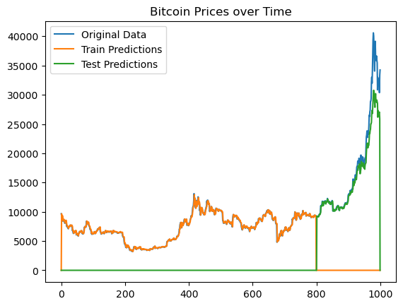

```python
train_predict_plot = np.empty_like(data)
train_predict_plot[:, :] = 0
train_predict_plot[look_back:len(y_pred_train)+look_back, :] = y_pred_train
test_predict_plot = np.empty_like(data)
test_predict_plot[:, :] = 0
test_predict_plot[len(y_pred_train)+(look_back*2)+1:len(data)-1, :] = y_pred_test

plt.plot(scaler.inverse_transform(scaled_data.copy()), label="Original Data")
plt.plot(train_predict_plot, label="Train Predictions")
plt.plot(test_predict_plot, label="Test Predictions")
plt.legend()
plt.title("Bitcoin Prices over Time")
plt.show()
```

Comparing the results of these first two models, we see that the Simple RNN model is more accurate at predicting the price of Bitcoin with a a day lookback and an 80/20 train test split. Next we will try to increase the lookback amount while keeping the same train test split.

## RNN Model Set 2 - 80/20 Split, 2 Day Lookback

### Simple RNN Model

```python
scaler = MinMaxScaler(feature_range=(0, 1))
scaled_data = scaler.fit_transform(data)

# Train test split of 80/20
train_size = int(len(scaled_data) * .8)
test_size = len(scaled_data) - train_size
train, test = scaled_data[0:train_size], scaled_data[train_size:]
print(len(train), len(test))

# Reshape dataset to X = t and y = t+1
# Look back 2 days
look_back = 2
X_train, y_train = create_dataset(train, look_back)
X_test, y_test = create_dataset(test, look_back)
print(X_train.shape, X_test.shape)

X_train = np.reshape(X_train, (X_train.shape[0], 1, X_train.shape[1]))
X_test = np.reshape(X_test, (X_test.shape[0], 1, X_test.shape[1]))
print(X_train.shape, X_test.shape)
```

```
800 200
(797, 2) (197, 2)
(797, 1, 2) (197, 1, 2)
```

```python
# Simple RNN Network
model = Sequential()
model.add(SimpleRNN(8, input_shape = (1, look_back)))
model.add(Dense(1))
model.compile(loss="mean_squared_error", optimizer="adam", metrics=["mean_squared_error"])
model.fit(X_train, y_train, epochs = 100, batch_size = 1, verbose = 2)
```

```
797/797 - 2s - 3ms/step - loss: 6.3168e-04 - mean_squared_error: 6.3168e-04
797/797 - 1s - 989us/step - loss: 1.1461e-04 - mean_squared_error: 1.1461e-04
797/797 - 1s - 994us/step - loss: 1.1413e-04 - mean_squared_error: 1.1413e-04
797/797 - 1s - 994us/step - loss: 1.0909e-04 - mean_squared_error: 1.0909e-04
797/797 - 1s - 991us/step - loss: 1.0112e-04 - mean_squared_error: 1.0112e-04
797/797 - 1s - 997us/step - loss: 1.0720e-04 - mean_squared_error: 1.0720e-04
797/797 - 1s - 998us/step - loss: 9.8362e-05 - mean_squared_error: 9.8362e-05
797/797 - 1s - 994us/step - loss: 9.8421e-05 - mean_squared_error: 9.8421e-05
797/797 - 1s - 985us/step - loss: 9.2137e-05 - mean_squared_error: 9.2137e-05
797/797 - 1s - 1ms/step - loss: 9.0938e-05 - mean_squared_error: 9.0938e-05
797/797 - 1s - 994us/step - loss: 8.5016e-05 - mean_squared_error: 8.5016e-05
797/797 - 1s - 993us/step - loss: 9.1591e-05 - mean_squared_error: 9.1591e-05
797/797 - 1s - 1ms/step - loss: 8.8753e-05 - mean_squared_error: 8.8753e-05
797/797 - 1s - 992us/step - loss: 8.4640e-05 - mean_squared_error: 8.4640e-05
797/797 - 1s - 991us/step - loss: 8.7551e-05 - mean_squared_error: 8.7551e-05
797/797 - 1s - 984us/step - loss: 7.9749e-05 - mean_squared_error: 7.9749e-05
797/797 - 1s - 991us/step - loss: 8.7871e-05 - mean_squared_error: 8.7871e-05
797/797 - 1s - 993us/step - loss: 8.6640e-05 - mean_squared_error: 8.6640e-05
797/797 - 1s - 994us/step - loss: 8.9710e-05 - mean_squared_error: 8.9710e-05
797/797 - 1s - 985us/step - loss: 8.8456e-05 - mean_squared_error: 8.8456e-05
797/797 - 1s - 993us/step - loss: 8.0288e-05 - mean_squared_error: 8.0288e-05
797/797 - 1s - 993us/step - loss: 8.3021e-05 - mean_squared_error: 8.3021e-05
797/797 - 1s - 995us/step - loss: 8.2614e-05 - mean_squared_error: 8.2614e-05
797/797 - 1s - 1ms/step - loss: 8.4956e-05 - mean_squared_error: 8.4956e-05
797/797 - 1s - 992us/step - loss: 8.2348e-05 - mean_squared_error: 8.2348e-05
797/797 - 1s - 1000us/step - loss: 8.3987e-05 - mean_squared_error: 8.3987e-05
797/797 - 1s - 996us/step - loss: 8.6056e-05 - mean_squared_error: 8.6056e-05
797/797 - 1s - 995us/step - loss: 7.7652e-05 - mean_squared_error: 7.7652e-05
797/797 - 1s - 1ms/step - loss: 8.0086e-05 - mean_squared_error: 8.0086e-05
797/797 - 1s - 992us/step - loss: 8.3939e-05 - mean_squared_error: 8.3939e-05
797/797 - 1s - 982us/step - loss: 7.9537e-05 - mean_squared_error: 7.9537e-05
797/797 - 1s - 990us/step - loss: 7.7737e-05 - mean_squared_error: 7.7737e-05
797/797 - 1s - 987us/step - loss: 8.0325e-05 - mean_squared_error: 8.0325e-05
797/797 - 1s - 989us/step - loss: 7.9924e-05 - mean_squared_error: 7.9924e-05
797/797 - 1s - 985us/step - loss: 8.0871e-05 - mean_squared_error: 8.0871e-05
797/797 - 1s - 994us/step - loss: 8.1129e-05 - mean_squared_error: 8.1129e-05
797/797 - 1s - 987us/step - loss: 8.0025e-05 - mean_squared_error: 8.0025e-05
797/797 - 1s - 1ms/step - loss: 8.0075e-05 - mean_squared_error: 8.0075e-05
797/797 - 1s - 986us/step - loss: 7.8314e-05 - mean_squared_error: 7.8314e-05
797/797 - 1s - 989us/step - loss: 8.0646e-05 - mean_squared_error: 8.0646e-05
```

[output cut: 45 more lines]

```
797/797 - 1s - 991us/step - loss: 7.6855e-05 - mean_squared_error: 7.6855e-05
797/797 - 1s - 988us/step - loss: 7.6267e-05 - mean_squared_error: 7.6267e-05
797/797 - 1s - 992us/step - loss: 7.6430e-05 - mean_squared_error: 7.6430e-05
797/797 - 1s - 992us/step - loss: 7.5972e-05 - mean_squared_error: 7.5972e-05
797/797 - 1s - 996us/step - loss: 7.4427e-05 - mean_squared_error: 7.4427e-05
797/797 - 1s - 1ms/step - loss: 7.4511e-05 - mean_squared_error: 7.4511e-05
797/797 - 1s - 998us/step - loss: 7.6545e-05 - mean_squared_error: 7.6545e-05
797/797 - 1s - 997us/step - loss: 7.6748e-05 - mean_squared_error: 7.6748e-05
797/797 - 1s - 995us/step - loss: 7.4779e-05 - mean_squared_error: 7.4779e-05
797/797 - 1s - 985us/step - loss: 7.5275e-05 - mean_squared_error: 7.5275e-05
797/797 - 1s - 987us/step - loss: 7.7628e-05 - mean_squared_error: 7.7628e-05
797/797 - 1s - 1ms/step - loss: 7.9581e-05 - mean_squared_error: 7.9581e-05
797/797 - 1s - 990us/step - loss: 7.4480e-05 - mean_squared_error: 7.4480e-05
797/797 - 1s - 995us/step - loss: 7.9948e-05 - mean_squared_error: 7.9948e-05
797/797 - 1s - 1ms/step - loss: 7.6976e-05 - mean_squared_error: 7.6976e-05
```

```
<keras.src.callbacks.history.History at 0x1763630d0>
```

```python
# Make predictions
y_pred_train = model.predict(X_train)
y_pred_test = model.predict(X_test)
# Unscale predictions
y_pred_train = scaler.inverse_transform(y_pred_train)
y_pred_test = scaler.inverse_transform(y_pred_test)
y_train = scaler.inverse_transform([y_train])
y_test = scaler.inverse_transform([y_test])
# Calculate RMSE
train_score = np.sqrt(mean_squared_error(y_train[0], y_pred_train[:,0]))
test_score = np.sqrt(mean_squared_error(y_test[0], y_pred_test[:, 0]))
print(f"Train RMSE: {train_score}")
print(f"Test RMSE: {test_score}")
```

```
25/25 ━━━━━━━━━━━━━━━━━━━━ 0s 6ms/step
7/7 ━━━━━━━━━━━━━━━━━━━━ 0s 1ms/step
Train RMSE: 320.069257234079
Test RMSE: 2750.8965784795982
```

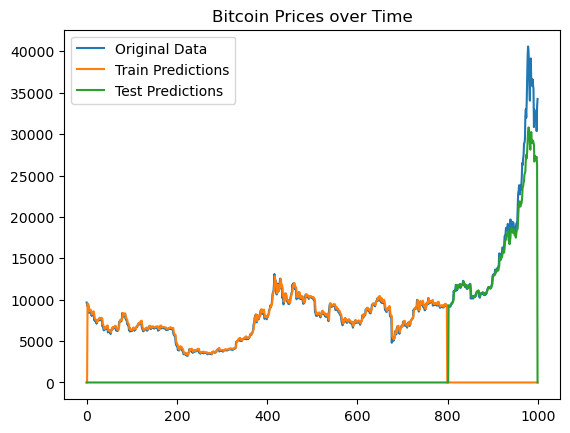

```python
train_predict_plot = np.empty_like(data)
train_predict_plot[:, :] = 0
train_predict_plot[look_back:len(y_pred_train)+look_back, :] = y_pred_train
test_predict_plot = np.empty_like(data)
test_predict_plot[:, :] = 0
test_predict_plot[len(y_pred_train)+(look_back*2)+1:len(data)-1, :] = y_pred_test

plt.plot(scaler.inverse_transform(scaled_data.copy()), label="Original Data")
plt.plot(train_predict_plot, label="Train Predictions")
plt.plot(test_predict_plot, label="Test Predictions")
plt.legend()
plt.title("Bitcoin Prices over Time")
plt.show()
```

### LSTM Model

```python
scaler = MinMaxScaler(feature_range=(0, 1))
scaled_data = scaler.fit_transform(data)

# Train test split of 80/20
train_size = int(len(scaled_data) * .8)
test_size = len(scaled_data) - train_size
train, test = scaled_data[0:train_size], scaled_data[train_size:]
print(len(train), len(test))

# Reshape dataset to X = t and y = t+1
# Look back 2 days
look_back = 2
X_train, y_train = create_dataset(train, look_back)
X_test, y_test = create_dataset(test, look_back)
print(X_train.shape, X_test.shape)

X_train = np.reshape(X_train, (X_train.shape[0], 1, X_train.shape[1]))
X_test = np.reshape(X_test, (X_test.shape[0], 1, X_test.shape[1]))
print(X_train.shape, X_test.shape)
```

```
800 200
(797, 2) (197, 2)
(797, 1, 2) (197, 1, 2)
```

```python
# LSTM Neural Network
model = Sequential()
model.add(LSTM(8, input_shape = (1, look_back)))
model.add(Dense(1))
model.compile(loss="mean_squared_error", optimizer="adam", metrics=["mean_squared_error"])
model.fit(X_train, y_train, epochs = 100, batch_size = 1, verbose = 2)
```

```
797/797 - 2s - 3ms/step - loss: 0.0011 - mean_squared_error: 0.0011
797/797 - 1s - 1ms/step - loss: 8.4757e-05 - mean_squared_error: 8.4757e-05
797/797 - 1s - 1ms/step - loss: 8.2298e-05 - mean_squared_error: 8.2298e-05
797/797 - 1s - 1ms/step - loss: 8.2148e-05 - mean_squared_error: 8.2148e-05
797/797 - 1s - 1ms/step - loss: 8.6613e-05 - mean_squared_error: 8.6613e-05
797/797 - 1s - 1ms/step - loss: 8.5453e-05 - mean_squared_error: 8.5453e-05
797/797 - 1s - 1ms/step - loss: 8.4834e-05 - mean_squared_error: 8.4834e-05
797/797 - 1s - 1ms/step - loss: 8.2666e-05 - mean_squared_error: 8.2666e-05
797/797 - 1s - 1ms/step - loss: 8.2889e-05 - mean_squared_error: 8.2889e-05
797/797 - 1s - 1ms/step - loss: 8.1047e-05 - mean_squared_error: 8.1047e-05
797/797 - 1s - 1ms/step - loss: 8.4896e-05 - mean_squared_error: 8.4896e-05
797/797 - 1s - 1ms/step - loss: 8.2472e-05 - mean_squared_error: 8.2472e-05
797/797 - 1s - 1ms/step - loss: 7.9845e-05 - mean_squared_error: 7.9845e-05
797/797 - 1s - 1ms/step - loss: 7.8568e-05 - mean_squared_error: 7.8568e-05
797/797 - 1s - 1ms/step - loss: 8.0916e-05 - mean_squared_error: 8.0916e-05
797/797 - 1s - 1ms/step - loss: 8.0028e-05 - mean_squared_error: 8.0028e-05
797/797 - 1s - 1ms/step - loss: 8.0936e-05 - mean_squared_error: 8.0936e-05
797/797 - 1s - 1ms/step - loss: 8.2418e-05 - mean_squared_error: 8.2418e-05
797/797 - 1s - 1ms/step - loss: 7.8954e-05 - mean_squared_error: 7.8954e-05
797/797 - 1s - 1ms/step - loss: 7.7246e-05 - mean_squared_error: 7.7246e-05
797/797 - 1s - 1ms/step - loss: 8.1297e-05 - mean_squared_error: 8.1297e-05
797/797 - 1s - 1ms/step - loss: 7.9560e-05 - mean_squared_error: 7.9560e-05
797/797 - 1s - 1ms/step - loss: 8.1552e-05 - mean_squared_error: 8.1552e-05
797/797 - 1s - 1ms/step - loss: 8.0043e-05 - mean_squared_error: 8.0043e-05
797/797 - 1s - 1ms/step - loss: 7.6792e-05 - mean_squared_error: 7.6792e-05
797/797 - 1s - 1ms/step - loss: 7.7926e-05 - mean_squared_error: 7.7926e-05
797/797 - 1s - 1ms/step - loss: 7.8996e-05 - mean_squared_error: 7.8996e-05
797/797 - 1s - 1ms/step - loss: 7.8939e-05 - mean_squared_error: 7.8939e-05
797/797 - 1s - 1ms/step - loss: 7.6570e-05 - mean_squared_error: 7.6570e-05
797/797 - 1s - 1ms/step - loss: 7.4279e-05 - mean_squared_error: 7.4279e-05
797/797 - 1s - 1ms/step - loss: 7.4749e-05 - mean_squared_error: 7.4749e-05
797/797 - 1s - 1ms/step - loss: 7.5268e-05 - mean_squared_error: 7.5268e-05
797/797 - 1s - 1ms/step - loss: 7.6788e-05 - mean_squared_error: 7.6788e-05
797/797 - 1s - 1ms/step - loss: 7.4824e-05 - mean_squared_error: 7.4824e-05
797/797 - 1s - 1ms/step - loss: 7.7269e-05 - mean_squared_error: 7.7269e-05
797/797 - 1s - 1ms/step - loss: 8.0764e-05 - mean_squared_error: 8.0764e-05
797/797 - 1s - 1ms/step - loss: 7.7974e-05 - mean_squared_error: 7.7974e-05
797/797 - 1s - 1ms/step - loss: 7.3951e-05 - mean_squared_error: 7.3951e-05
797/797 - 1s - 1ms/step - loss: 7.8665e-05 - mean_squared_error: 7.8665e-05
797/797 - 1s - 1ms/step - loss: 7.6661e-05 - mean_squared_error: 7.6661e-05
```

[output cut: 45 more lines]

```
797/797 - 1s - 1ms/step - loss: 7.1818e-05 - mean_squared_error: 7.1818e-05
797/797 - 1s - 1ms/step - loss: 7.5651e-05 - mean_squared_error: 7.5651e-05
797/797 - 1s - 1ms/step - loss: 7.2635e-05 - mean_squared_error: 7.2635e-05
797/797 - 1s - 1ms/step - loss: 7.4505e-05 - mean_squared_error: 7.4505e-05
797/797 - 1s - 1ms/step - loss: 7.8671e-05 - mean_squared_error: 7.8671e-05
797/797 - 1s - 1ms/step - loss: 7.6072e-05 - mean_squared_error: 7.6072e-05
797/797 - 1s - 1ms/step - loss: 7.5296e-05 - mean_squared_error: 7.5296e-05
797/797 - 1s - 1ms/step - loss: 7.4661e-05 - mean_squared_error: 7.4661e-05
797/797 - 1s - 1ms/step - loss: 7.5507e-05 - mean_squared_error: 7.5507e-05
797/797 - 1s - 1ms/step - loss: 7.3603e-05 - mean_squared_error: 7.3603e-05
797/797 - 1s - 1ms/step - loss: 7.6961e-05 - mean_squared_error: 7.6961e-05
797/797 - 1s - 1ms/step - loss: 7.0381e-05 - mean_squared_error: 7.0381e-05
797/797 - 1s - 1ms/step - loss: 7.1501e-05 - mean_squared_error: 7.1501e-05
797/797 - 1s - 1ms/step - loss: 7.4703e-05 - mean_squared_error: 7.4703e-05
797/797 - 1s - 1ms/step - loss: 7.5432e-05 - mean_squared_error: 7.5432e-05
```

```
<keras.src.callbacks.history.History at 0x1767c3290>
```

```python
# Make predictions
y_pred_train = model.predict(X_train)
y_pred_test = model.predict(X_test)
# Unscale predictions
y_pred_train = scaler.inverse_transform(y_pred_train)
y_pred_test = scaler.inverse_transform(y_pred_test)
y_train = scaler.inverse_transform([y_train])
y_test = scaler.inverse_transform([y_test])
# Calculate RMSE
train_score = np.sqrt(mean_squared_error(y_train[0], y_pred_train[:,0]))
test_score = np.sqrt(mean_squared_error(y_test[0], y_pred_test[:, 0]))
print(f"Train RMSE: {train_score}")
print(f"Test RMSE: {test_score}")
```

```
25/25 ━━━━━━━━━━━━━━━━━━━━ 0s 8ms/step
7/7 ━━━━━━━━━━━━━━━━━━━━ 0s 1ms/step
Train RMSE: 344.3774273579589
Test RMSE: 2994.5401457628927
```

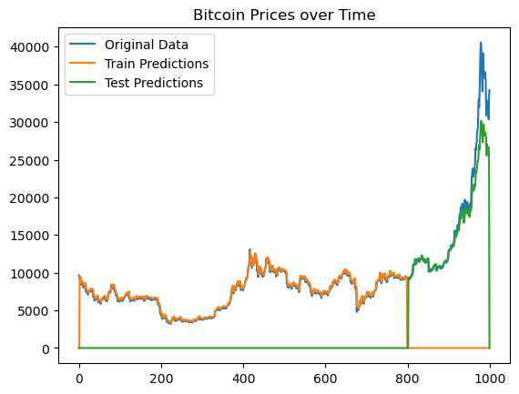

```python
train_predict_plot = np.empty_like(data)
train_predict_plot[:, :] = 0
train_predict_plot[look_back:len(y_pred_train)+look_back, :] = y_pred_train
test_predict_plot = np.empty_like(data)
test_predict_plot[:, :] = 0
test_predict_plot[len(y_pred_train)+(look_back*2)+1:len(data)-1, :] = y_pred_test

plt.plot(scaler.inverse_transform(scaled_data.copy()), label="Original Data")
plt.plot(train_predict_plot, label="Train Predictions")
plt.plot(test_predict_plot, label="Test Predictions")
plt.legend()
plt.title("Bitcoin Prices over Time")
plt.show()
```

Increasing the lookback time to two days resulted in both models performing less well than with the previous value of one day. Now we will return to a one day lookback value and change the train test split to 70/30.

## RNN Model Set 3 - 70/30 Split, 1 Day Lookback

### Simple RNN Model

```python
scaler = MinMaxScaler(feature_range=(0, 1))
scaled_data = scaler.fit_transform(data)

# Train test split of 70/30
train_size = int(len(scaled_data) * .7)
test_size = len(scaled_data) - train_size
train, test = scaled_data[0:train_size], scaled_data[train_size:]
print(len(train), len(test))

# Reshape dataset to X = t and y = t+1
# Look back 1 day
look_back = 1
X_train, y_train = create_dataset(train, look_back)
X_test, y_test = create_dataset(test, look_back)
print(X_train.shape, X_test.shape)

X_train = np.reshape(X_train, (X_train.shape[0], 1, X_train.shape[1]))
X_test = np.reshape(X_test, (X_test.shape[0], 1, X_test.shape[1]))
print(X_train.shape, X_test.shape)
```

```
700 300
(698, 1) (298, 1)
(698, 1, 1) (298, 1, 1)
```

```python
# Simple RNN Network
model = Sequential()
model.add(SimpleRNN(8, input_shape = (1, look_back)))
model.add(Dense(1))
model.compile(loss="mean_squared_error", optimizer="adam", metrics=["mean_squared_error"])
model.fit(X_train, y_train, epochs = 100, batch_size = 1, verbose = 2)
```

```
698/698 - 2s - 3ms/step - loss: 0.0020 - mean_squared_error: 0.0020
698/698 - 1s - 986us/step - loss: 8.4811e-05 - mean_squared_error: 8.4811e-05
698/698 - 1s - 1ms/step - loss: 7.6605e-05 - mean_squared_error: 7.6605e-05
698/698 - 1s - 987us/step - loss: 7.7578e-05 - mean_squared_error: 7.7578e-05
698/698 - 1s - 999us/step - loss: 8.0319e-05 - mean_squared_error: 8.0319e-05
698/698 - 1s - 1ms/step - loss: 8.3256e-05 - mean_squared_error: 8.3256e-05
698/698 - 1s - 1ms/step - loss: 8.7949e-05 - mean_squared_error: 8.7949e-05
698/698 - 1s - 997us/step - loss: 8.3028e-05 - mean_squared_error: 8.3028e-05
698/698 - 1s - 1ms/step - loss: 8.9423e-05 - mean_squared_error: 8.9423e-05
698/698 - 1s - 999us/step - loss: 8.2018e-05 - mean_squared_error: 8.2018e-05
698/698 - 1s - 1ms/step - loss: 8.4073e-05 - mean_squared_error: 8.4073e-05
698/698 - 1s - 1ms/step - loss: 8.1698e-05 - mean_squared_error: 8.1698e-05
698/698 - 1s - 1ms/step - loss: 7.5437e-05 - mean_squared_error: 7.5437e-05
698/698 - 1s - 1ms/step - loss: 8.5354e-05 - mean_squared_error: 8.5354e-05
698/698 - 1s - 990us/step - loss: 8.4052e-05 - mean_squared_error: 8.4052e-05
698/698 - 1s - 995us/step - loss: 8.6068e-05 - mean_squared_error: 8.6068e-05
698/698 - 1s - 1ms/step - loss: 7.7223e-05 - mean_squared_error: 7.7223e-05
698/698 - 1s - 1ms/step - loss: 8.8406e-05 - mean_squared_error: 8.8406e-05
698/698 - 1s - 991us/step - loss: 7.6798e-05 - mean_squared_error: 7.6798e-05
698/698 - 1s - 988us/step - loss: 8.3804e-05 - mean_squared_error: 8.3804e-05
698/698 - 1s - 1ms/step - loss: 8.0178e-05 - mean_squared_error: 8.0178e-05
698/698 - 1s - 991us/step - loss: 7.7367e-05 - mean_squared_error: 7.7367e-05
698/698 - 1s - 996us/step - loss: 8.6329e-05 - mean_squared_error: 8.6329e-05
698/698 - 1s - 990us/step - loss: 8.3974e-05 - mean_squared_error: 8.3974e-05
698/698 - 1s - 990us/step - loss: 8.0863e-05 - mean_squared_error: 8.0863e-05
698/698 - 1s - 993us/step - loss: 8.0957e-05 - mean_squared_error: 8.0957e-05
698/698 - 1s - 993us/step - loss: 8.2178e-05 - mean_squared_error: 8.2178e-05
698/698 - 1s - 992us/step - loss: 8.3445e-05 - mean_squared_error: 8.3445e-05
698/698 - 1s - 989us/step - loss: 7.7259e-05 - mean_squared_error: 7.7259e-05
698/698 - 1s - 995us/step - loss: 8.0024e-05 - mean_squared_error: 8.0024e-05
698/698 - 1s - 995us/step - loss: 7.8327e-05 - mean_squared_error: 7.8327e-05
698/698 - 1s - 995us/step - loss: 7.5550e-05 - mean_squared_error: 7.5550e-05
698/698 - 1s - 1000us/step - loss: 7.7073e-05 - mean_squared_error: 7.7073e-05
698/698 - 1s - 1ms/step - loss: 7.8243e-05 - mean_squared_error: 7.8243e-05
698/698 - 1s - 1ms/step - loss: 7.7721e-05 - mean_squared_error: 7.7721e-05
698/698 - 1s - 993us/step - loss: 7.6983e-05 - mean_squared_error: 7.6983e-05
698/698 - 1s - 996us/step - loss: 7.9517e-05 - mean_squared_error: 7.9517e-05
698/698 - 1s - 995us/step - loss: 7.8876e-05 - mean_squared_error: 7.8876e-05
698/698 - 1s - 996us/step - loss: 7.6915e-05 - mean_squared_error: 7.6915e-05
698/698 - 1s - 994us/step - loss: 7.8919e-05 - mean_squared_error: 7.8919e-05
```

[output cut: 45 more lines]

```
698/698 - 1s - 992us/step - loss: 7.9590e-05 - mean_squared_error: 7.9590e-05
698/698 - 1s - 1ms/step - loss: 7.2879e-05 - mean_squared_error: 7.2879e-05
698/698 - 1s - 1ms/step - loss: 7.4657e-05 - mean_squared_error: 7.4657e-05
698/698 - 1s - 1ms/step - loss: 7.8530e-05 - mean_squared_error: 7.8530e-05
698/698 - 1s - 994us/step - loss: 7.4224e-05 - mean_squared_error: 7.4224e-05
698/698 - 1s - 1ms/step - loss: 7.3956e-05 - mean_squared_error: 7.3956e-05
698/698 - 1s - 993us/step - loss: 7.5010e-05 - mean_squared_error: 7.5010e-05
698/698 - 1s - 1ms/step - loss: 7.6031e-05 - mean_squared_error: 7.6031e-05
698/698 - 1s - 997us/step - loss: 7.3783e-05 - mean_squared_error: 7.3783e-05
698/698 - 1s - 1ms/step - loss: 7.5993e-05 - mean_squared_error: 7.5993e-05
698/698 - 1s - 991us/step - loss: 7.4324e-05 - mean_squared_error: 7.4324e-05
698/698 - 1s - 995us/step - loss: 7.3668e-05 - mean_squared_error: 7.3668e-05
698/698 - 1s - 997us/step - loss: 7.7506e-05 - mean_squared_error: 7.7506e-05
698/698 - 1s - 994us/step - loss: 7.8047e-05 - mean_squared_error: 7.8047e-05
698/698 - 1s - 1ms/step - loss: 7.5242e-05 - mean_squared_error: 7.5242e-05
```

```
<keras.src.callbacks.history.History at 0x176b93710>
```

```python
# Make predictions
y_pred_train = model.predict(X_train)
y_pred_test = model.predict(X_test)
# Unscale predictions
y_pred_train = scaler.inverse_transform(y_pred_train)
y_pred_test = scaler.inverse_transform(y_pred_test)
y_train = scaler.inverse_transform([y_train])
y_test = scaler.inverse_transform([y_test])
# Calculate RMSE
train_score = np.sqrt(mean_squared_error(y_train[0], y_pred_train[:,0]))
test_score = np.sqrt(mean_squared_error(y_test[0], y_pred_test[:, 0]))
print(f"Train RMSE: {train_score}")
print(f"Test RMSE: {test_score}")
```

```
22/22 ━━━━━━━━━━━━━━━━━━━━ 0s 7ms/step
10/10 ━━━━━━━━━━━━━━━━━━━━ 0s 1ms/step
Train RMSE: 303.7730483392023
Test RMSE: 1675.120934848082
```

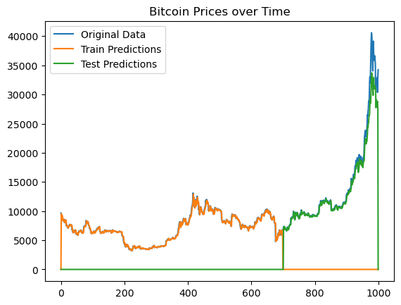

```python
train_predict_plot = np.empty_like(data)
train_predict_plot[:, :] = 0
train_predict_plot[look_back:len(y_pred_train)+look_back, :] = y_pred_train
test_predict_plot = np.empty_like(data)
test_predict_plot[:, :] = 0
test_predict_plot[len(y_pred_train)+(look_back*2)+1:len(data)-1, :] = y_pred_test

plt.plot(scaler.inverse_transform(scaled_data.copy()), label="Original Data")
plt.plot(train_predict_plot, label="Train Predictions")
plt.plot(test_predict_plot, label="Test Predictions")
plt.legend()
plt.title("Bitcoin Prices over Time")
plt.show()
```

### LSTM Model

```python
scaler = MinMaxScaler(feature_range=(0, 1))
scaled_data = scaler.fit_transform(data)

# Train test split of 70/30
train_size = int(len(scaled_data) * .7)
test_size = len(scaled_data) - train_size
train, test = scaled_data[0:train_size], scaled_data[train_size:]
print(len(train), len(test))

# Reshape dataset to X = t and y = t+1
# Look back 1 day
look_back = 1
X_train, y_train = create_dataset(train, look_back)
X_test, y_test = create_dataset(test, look_back)
print(X_train.shape, X_test.shape)

X_train = np.reshape(X_train, (X_train.shape[0], 1, X_train.shape[1]))
X_test = np.reshape(X_test, (X_test.shape[0], 1, X_test.shape[1]))
print(X_train.shape, X_test.shape)
```

```
700 300
(698, 1) (298, 1)
(698, 1, 1) (298, 1, 1)
```

```python
# LSTM Neural Network
model = Sequential()
model.add(LSTM(8, input_shape = (1, look_back)))
model.add(Dense(1))
model.compile(loss="mean_squared_error", optimizer="adam", metrics=["mean_squared_error"])
model.fit(X_train, y_train, epochs = 100, batch_size = 1, verbose = 2)
```

```
698/698 - 2s - 3ms/step - loss: 0.0027 - mean_squared_error: 0.0027
698/698 - 1s - 1ms/step - loss: 3.8832e-04 - mean_squared_error: 3.8832e-04
698/698 - 1s - 1ms/step - loss: 7.6527e-05 - mean_squared_error: 7.6527e-05
698/698 - 1s - 1ms/step - loss: 7.4730e-05 - mean_squared_error: 7.4730e-05
698/698 - 1s - 1ms/step - loss: 7.7081e-05 - mean_squared_error: 7.7081e-05
698/698 - 1s - 1ms/step - loss: 7.8112e-05 - mean_squared_error: 7.8112e-05
698/698 - 1s - 1ms/step - loss: 7.8217e-05 - mean_squared_error: 7.8217e-05
698/698 - 1s - 1ms/step - loss: 7.5043e-05 - mean_squared_error: 7.5043e-05
698/698 - 1s - 1ms/step - loss: 7.8188e-05 - mean_squared_error: 7.8188e-05
698/698 - 1s - 1ms/step - loss: 7.7585e-05 - mean_squared_error: 7.7585e-05
698/698 - 1s - 1ms/step - loss: 7.7670e-05 - mean_squared_error: 7.7670e-05
698/698 - 1s - 1ms/step - loss: 7.8535e-05 - mean_squared_error: 7.8535e-05
698/698 - 1s - 1ms/step - loss: 7.7074e-05 - mean_squared_error: 7.7074e-05
698/698 - 1s - 1ms/step - loss: 8.1424e-05 - mean_squared_error: 8.1424e-05
698/698 - 1s - 1ms/step - loss: 7.9811e-05 - mean_squared_error: 7.9811e-05
698/698 - 1s - 1ms/step - loss: 7.9177e-05 - mean_squared_error: 7.9177e-05
698/698 - 1s - 1ms/step - loss: 7.8155e-05 - mean_squared_error: 7.8155e-05
698/698 - 1s - 1ms/step - loss: 7.5025e-05 - mean_squared_error: 7.5025e-05
698/698 - 1s - 1ms/step - loss: 7.8722e-05 - mean_squared_error: 7.8722e-05
698/698 - 1s - 1ms/step - loss: 8.2438e-05 - mean_squared_error: 8.2438e-05
698/698 - 1s - 1ms/step - loss: 8.0132e-05 - mean_squared_error: 8.0132e-05
698/698 - 1s - 1ms/step - loss: 8.0745e-05 - mean_squared_error: 8.0745e-05
698/698 - 1s - 1ms/step - loss: 7.6984e-05 - mean_squared_error: 7.6984e-05
698/698 - 1s - 1ms/step - loss: 7.5776e-05 - mean_squared_error: 7.5776e-05
698/698 - 1s - 1ms/step - loss: 7.9481e-05 - mean_squared_error: 7.9481e-05
698/698 - 1s - 1ms/step - loss: 7.7496e-05 - mean_squared_error: 7.7496e-05
698/698 - 1s - 1ms/step - loss: 7.7499e-05 - mean_squared_error: 7.7499e-05
698/698 - 1s - 1ms/step - loss: 7.4345e-05 - mean_squared_error: 7.4345e-05
698/698 - 1s - 1ms/step - loss: 7.6959e-05 - mean_squared_error: 7.6959e-05
698/698 - 1s - 1ms/step - loss: 7.6688e-05 - mean_squared_error: 7.6688e-05
698/698 - 1s - 1ms/step - loss: 7.7013e-05 - mean_squared_error: 7.7013e-05
698/698 - 1s - 1ms/step - loss: 7.8942e-05 - mean_squared_error: 7.8942e-05
698/698 - 1s - 1ms/step - loss: 8.1762e-05 - mean_squared_error: 8.1762e-05
698/698 - 1s - 1ms/step - loss: 7.5215e-05 - mean_squared_error: 7.5215e-05
698/698 - 1s - 1ms/step - loss: 7.5958e-05 - mean_squared_error: 7.5958e-05
698/698 - 1s - 1ms/step - loss: 7.7936e-05 - mean_squared_error: 7.7936e-05
698/698 - 1s - 1ms/step - loss: 7.9182e-05 - mean_squared_error: 7.9182e-05
698/698 - 1s - 1ms/step - loss: 7.7730e-05 - mean_squared_error: 7.7730e-05
698/698 - 1s - 1ms/step - loss: 7.6357e-05 - mean_squared_error: 7.6357e-05
698/698 - 1s - 1ms/step - loss: 7.3886e-05 - mean_squared_error: 7.3886e-05
```

[output cut: 45 more lines]

```
698/698 - 1s - 1ms/step - loss: 7.6685e-05 - mean_squared_error: 7.6685e-05
698/698 - 1s - 1ms/step - loss: 7.8697e-05 - mean_squared_error: 7.8697e-05
698/698 - 1s - 1ms/step - loss: 7.3933e-05 - mean_squared_error: 7.3933e-05
698/698 - 1s - 1ms/step - loss: 7.3625e-05 - mean_squared_error: 7.3625e-05
698/698 - 1s - 1ms/step - loss: 7.7464e-05 - mean_squared_error: 7.7464e-05
698/698 - 1s - 1ms/step - loss: 7.5994e-05 - mean_squared_error: 7.5994e-05
698/698 - 1s - 1ms/step - loss: 7.3586e-05 - mean_squared_error: 7.3586e-05
698/698 - 1s - 1ms/step - loss: 7.8784e-05 - mean_squared_error: 7.8784e-05
698/698 - 1s - 1ms/step - loss: 7.7094e-05 - mean_squared_error: 7.7094e-05
698/698 - 1s - 1ms/step - loss: 7.8043e-05 - mean_squared_error: 7.8043e-05
698/698 - 1s - 1ms/step - loss: 7.3732e-05 - mean_squared_error: 7.3732e-05
698/698 - 1s - 1ms/step - loss: 7.9132e-05 - mean_squared_error: 7.9132e-05
698/698 - 1s - 1ms/step - loss: 7.6620e-05 - mean_squared_error: 7.6620e-05
698/698 - 1s - 1ms/step - loss: 7.4441e-05 - mean_squared_error: 7.4441e-05
698/698 - 1s - 1ms/step - loss: 7.9296e-05 - mean_squared_error: 7.9296e-05
```

```
<keras.src.callbacks.history.History at 0x17676be50>
```

```python
# Make predictions
y_pred_train = model.predict(X_train)
y_pred_test = model.predict(X_test)
# Unscale predictions
y_pred_train = scaler.inverse_transform(y_pred_train)
y_pred_test = scaler.inverse_transform(y_pred_test)
y_train = scaler.inverse_transform([y_train])
y_test = scaler.inverse_transform([y_test])
# Calculate RMSE
train_score = np.sqrt(mean_squared_error(y_train[0], y_pred_train[:,0]))
test_score = np.sqrt(mean_squared_error(y_test[0], y_pred_test[:, 0]))
print(f"Train RMSE: {train_score}")
print(f"Test RMSE: {test_score}")
```

```
22/22 ━━━━━━━━━━━━━━━━━━━━ 0s 8ms/step
10/10 ━━━━━━━━━━━━━━━━━━━━ 0s 1ms/step
Train RMSE: 343.43264913478015
Test RMSE: 2632.272982853638
```

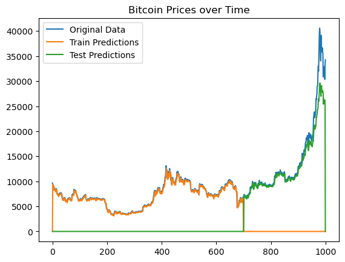

```python
train_predict_plot = np.empty_like(data)
train_predict_plot[:, :] = 0
train_predict_plot[look_back:len(y_pred_train)+look_back, :] = y_pred_train
test_predict_plot = np.empty_like(data)
test_predict_plot[:, :] = 0
test_predict_plot[len(y_pred_train)+(look_back*2)+1:len(data)-1, :] = y_pred_test

plt.plot(scaler.inverse_transform(scaled_data.copy()), label="Original Data")
plt.plot(train_predict_plot, label="Train Predictions")
plt.plot(test_predict_plot, label="Test Predictions")
plt.legend()
plt.title("Bitcoin Prices over Time")
plt.show()
```

### Simple RNN Model 1

We will make this a smaller model than the previous Simple RNN models to see how the number of layers impacts the network.

```python
scaler = MinMaxScaler(feature_range=(0, 1))
scaled_data = scaler.fit_transform(data)

# Train test split of 70/30
train_size = int(len(scaled_data) * .7)
test_size = len(scaled_data) - train_size
train, test = scaled_data[0:train_size], scaled_data[train_size:]
print(len(train), len(test))

# Reshape dataset to X = t and y = t+1
# Look back 1 day
look_back = 1
X_train, y_train = create_dataset(train, look_back)
X_test, y_test = create_dataset(test, look_back)
print(X_train.shape, X_test.shape)

X_train = np.reshape(X_train, (X_train.shape[0], 1, X_train.shape[1]))
X_test = np.reshape(X_test, (X_test.shape[0], 1, X_test.shape[1]))
print(X_train.shape, X_test.shape)
```

```
700 300
(698, 1) (298, 1)
(698, 1, 1) (298, 1, 1)
```

```python
# Simple RNN Network
model = Sequential()
model.add(SimpleRNN(4, input_shape = (1, look_back)))
model.add(Dense(1))
model.compile(loss="mean_squared_error", optimizer="adam", metrics=["mean_squared_error"])
model.fit(X_train, y_train, epochs = 100, batch_size = 1, verbose = 2)
```

```
698/698 - 2s - 3ms/step - loss: 7.5161e-04 - mean_squared_error: 7.5161e-04
698/698 - 1s - 993us/step - loss: 7.7519e-05 - mean_squared_error: 7.7519e-05
698/698 - 1s - 991us/step - loss: 7.3453e-05 - mean_squared_error: 7.3453e-05
698/698 - 1s - 992us/step - loss: 7.5935e-05 - mean_squared_error: 7.5935e-05
698/698 - 1s - 996us/step - loss: 7.8735e-05 - mean_squared_error: 7.8735e-05
698/698 - 1s - 998us/step - loss: 7.8390e-05 - mean_squared_error: 7.8390e-05
698/698 - 1s - 992us/step - loss: 7.8094e-05 - mean_squared_error: 7.8094e-05
698/698 - 1s - 1ms/step - loss: 7.5997e-05 - mean_squared_error: 7.5997e-05
698/698 - 1s - 999us/step - loss: 8.5259e-05 - mean_squared_error: 8.5259e-05
698/698 - 1s - 1ms/step - loss: 7.8366e-05 - mean_squared_error: 7.8366e-05
698/698 - 1s - 993us/step - loss: 8.1468e-05 - mean_squared_error: 8.1468e-05
698/698 - 1s - 999us/step - loss: 8.1848e-05 - mean_squared_error: 8.1848e-05
698/698 - 1s - 993us/step - loss: 8.3177e-05 - mean_squared_error: 8.3177e-05
698/698 - 1s - 988us/step - loss: 8.1291e-05 - mean_squared_error: 8.1291e-05
698/698 - 1s - 993us/step - loss: 8.5236e-05 - mean_squared_error: 8.5236e-05
698/698 - 1s - 997us/step - loss: 8.1138e-05 - mean_squared_error: 8.1138e-05
698/698 - 1s - 1ms/step - loss: 7.7691e-05 - mean_squared_error: 7.7691e-05
698/698 - 1s - 990us/step - loss: 7.9429e-05 - mean_squared_error: 7.9429e-05
698/698 - 1s - 998us/step - loss: 7.9157e-05 - mean_squared_error: 7.9157e-05
698/698 - 1s - 996us/step - loss: 7.9621e-05 - mean_squared_error: 7.9621e-05
698/698 - 1s - 990us/step - loss: 7.6576e-05 - mean_squared_error: 7.6576e-05
698/698 - 1s - 992us/step - loss: 8.0720e-05 - mean_squared_error: 8.0720e-05
698/698 - 1s - 988us/step - loss: 7.6009e-05 - mean_squared_error: 7.6009e-05
698/698 - 1s - 990us/step - loss: 8.2482e-05 - mean_squared_error: 8.2482e-05
698/698 - 1s - 991us/step - loss: 7.8304e-05 - mean_squared_error: 7.8304e-05
698/698 - 1s - 987us/step - loss: 7.7566e-05 - mean_squared_error: 7.7566e-05
698/698 - 1s - 1ms/step - loss: 7.7734e-05 - mean_squared_error: 7.7734e-05
698/698 - 1s - 1ms/step - loss: 7.6892e-05 - mean_squared_error: 7.6892e-05
698/698 - 1s - 1ms/step - loss: 7.8666e-05 - mean_squared_error: 7.8666e-05
698/698 - 1s - 984us/step - loss: 7.9113e-05 - mean_squared_error: 7.9113e-05
698/698 - 1s - 996us/step - loss: 8.1108e-05 - mean_squared_error: 8.1108e-05
698/698 - 1s - 1ms/step - loss: 7.7372e-05 - mean_squared_error: 7.7372e-05
698/698 - 1s - 1ms/step - loss: 8.0254e-05 - mean_squared_error: 8.0254e-05
698/698 - 1s - 1ms/step - loss: 8.0057e-05 - mean_squared_error: 8.0057e-05
698/698 - 1s - 984us/step - loss: 8.0141e-05 - mean_squared_error: 8.0141e-05
698/698 - 1s - 997us/step - loss: 8.3140e-05 - mean_squared_error: 8.3140e-05
698/698 - 1s - 993us/step - loss: 7.9427e-05 - mean_squared_error: 7.9427e-05
698/698 - 1s - 1ms/step - loss: 7.9423e-05 - mean_squared_error: 7.9423e-05
698/698 - 1s - 994us/step - loss: 7.7178e-05 - mean_squared_error: 7.7178e-05
698/698 - 1s - 988us/step - loss: 7.8682e-05 - mean_squared_error: 7.8682e-05
```

[output cut: 45 more lines]

```
698/698 - 1s - 989us/step - loss: 7.4071e-05 - mean_squared_error: 7.4071e-05
698/698 - 1s - 985us/step - loss: 7.9436e-05 - mean_squared_error: 7.9436e-05
698/698 - 1s - 986us/step - loss: 7.4340e-05 - mean_squared_error: 7.4340e-05
698/698 - 1s - 986us/step - loss: 7.4899e-05 - mean_squared_error: 7.4899e-05
698/698 - 1s - 991us/step - loss: 7.4478e-05 - mean_squared_error: 7.4478e-05
698/698 - 1s - 984us/step - loss: 7.6082e-05 - mean_squared_error: 7.6082e-05
698/698 - 1s - 997us/step - loss: 7.2986e-05 - mean_squared_error: 7.2986e-05
698/698 - 1s - 986us/step - loss: 7.4878e-05 - mean_squared_error: 7.4878e-05
698/698 - 1s - 984us/step - loss: 7.7641e-05 - mean_squared_error: 7.7641e-05
698/698 - 1s - 988us/step - loss: 7.5318e-05 - mean_squared_error: 7.5318e-05
698/698 - 1s - 983us/step - loss: 7.5121e-05 - mean_squared_error: 7.5121e-05
698/698 - 1s - 1ms/step - loss: 7.9303e-05 - mean_squared_error: 7.9303e-05
698/698 - 1s - 1ms/step - loss: 7.4708e-05 - mean_squared_error: 7.4708e-05
698/698 - 1s - 990us/step - loss: 7.6156e-05 - mean_squared_error: 7.6156e-05
698/698 - 1s - 995us/step - loss: 7.5569e-05 - mean_squared_error: 7.5569e-05
```

```
<keras.src.callbacks.history.History at 0x176fa7e90>
```

```python
# Make predictions
y_pred_train = model.predict(X_train)
y_pred_test = model.predict(X_test)
# Unscale predictions
y_pred_train = scaler.inverse_transform(y_pred_train)
y_pred_test = scaler.inverse_transform(y_pred_test)
y_train = scaler.inverse_transform([y_train])
y_test = scaler.inverse_transform([y_test])
# Calculate RMSE
train_score = np.sqrt(mean_squared_error(y_train[0], y_pred_train[:,0]))
test_score = np.sqrt(mean_squared_error(y_test[0], y_pred_test[:, 0]))
print(f"Train RMSE: {train_score}")
print(f"Test RMSE: {test_score}")
```

```
22/22 ━━━━━━━━━━━━━━━━━━━━ 0s 7ms/step
10/10 ━━━━━━━━━━━━━━━━━━━━ 0s 1ms/step
Train RMSE: 377.12475837297757
Test RMSE: 1946.0306274331206
```

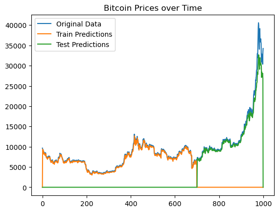

```python
train_predict_plot = np.empty_like(data)
train_predict_plot[:, :] = 0
train_predict_plot[look_back:len(y_pred_train)+look_back, :] = y_pred_train
test_predict_plot = np.empty_like(data)
test_predict_plot[:, :] = 0
test_predict_plot[len(y_pred_train)+(look_back*2)+1:len(data)-1, :] = y_pred_test

plt.plot(scaler.inverse_transform(scaled_data.copy()), label="Original Data")
plt.plot(train_predict_plot, label="Train Predictions")
plt.plot(test_predict_plot, label="Test Predictions")
plt.legend()
plt.title("Bitcoin Prices over Time")
plt.show()
```

Comparing this model to the previous Simple RNN model, it appears that halving the size of the network has had a slightly negative effect on the predictions, but it is much closer to the original model than I expected. Now we will try increasing size of the network.

### Simple RNN Model 2

Our two previous Simple RNN models had layer sizes of 8 and 4, now we will try using a layer size of 16 to see if we can further increase performance.

```python
scaler = MinMaxScaler(feature_range=(0, 1))
scaled_data = scaler.fit_transform(data)

# Train test split of 70/30
train_size = int(len(scaled_data) * .7)
test_size = len(scaled_data) - train_size
train, test = scaled_data[0:train_size], scaled_data[train_size:]
print(len(train), len(test))

# Reshape dataset to X = t and y = t+1
# Look back 1 day
look_back = 1
X_train, y_train = create_dataset(train, look_back)
X_test, y_test = create_dataset(test, look_back)
print(X_train.shape, X_test.shape)

X_train = np.reshape(X_train, (X_train.shape[0], 1, X_train.shape[1]))
X_test = np.reshape(X_test, (X_test.shape[0], 1, X_test.shape[1]))
print(X_train.shape, X_test.shape)
```

```
700 300
(698, 1) (298, 1)
(698, 1, 1) (298, 1, 1)
```

```python
# Simple RNN Network
model = Sequential()
model.add(SimpleRNN(16, input_shape = (1, look_back)))
model.add(Dense(1))
model.compile(loss="mean_squared_error", optimizer="adam", metrics=["mean_squared_error"])
model.fit(X_train, y_train, epochs = 100, batch_size = 1, verbose = 2)
```

```
698/698 - 2s - 3ms/step - loss: 0.0067 - mean_squared_error: 0.0067
698/698 - 1s - 999us/step - loss: 2.1193e-04 - mean_squared_error: 2.1193e-04
698/698 - 1s - 1ms/step - loss: 7.2197e-05 - mean_squared_error: 7.2197e-05
698/698 - 1s - 1ms/step - loss: 7.4316e-05 - mean_squared_error: 7.4316e-05
698/698 - 1s - 998us/step - loss: 7.8240e-05 - mean_squared_error: 7.8240e-05
698/698 - 1s - 1ms/step - loss: 8.2802e-05 - mean_squared_error: 8.2802e-05
698/698 - 1s - 1ms/step - loss: 8.2068e-05 - mean_squared_error: 8.2068e-05
698/698 - 1s - 1000us/step - loss: 7.8197e-05 - mean_squared_error: 7.8197e-05
698/698 - 1s - 1ms/step - loss: 8.9785e-05 - mean_squared_error: 8.9785e-05
698/698 - 1s - 1ms/step - loss: 8.1315e-05 - mean_squared_error: 8.1315e-05
698/698 - 1s - 1000us/step - loss: 8.2042e-05 - mean_squared_error: 8.2042e-05
698/698 - 1s - 995us/step - loss: 8.1812e-05 - mean_squared_error: 8.1812e-05
698/698 - 1s - 1ms/step - loss: 8.5259e-05 - mean_squared_error: 8.5259e-05
698/698 - 1s - 1ms/step - loss: 8.4605e-05 - mean_squared_error: 8.4605e-05
698/698 - 1s - 1ms/step - loss: 7.9873e-05 - mean_squared_error: 7.9873e-05
698/698 - 1s - 991us/step - loss: 8.2913e-05 - mean_squared_error: 8.2913e-05
698/698 - 1s - 1ms/step - loss: 7.9612e-05 - mean_squared_error: 7.9612e-05
698/698 - 1s - 1ms/step - loss: 8.3505e-05 - mean_squared_error: 8.3505e-05
698/698 - 1s - 1ms/step - loss: 7.8187e-05 - mean_squared_error: 7.8187e-05
698/698 - 1s - 1ms/step - loss: 8.2330e-05 - mean_squared_error: 8.2330e-05
698/698 - 1s - 998us/step - loss: 8.1030e-05 - mean_squared_error: 8.1030e-05
698/698 - 1s - 995us/step - loss: 7.9004e-05 - mean_squared_error: 7.9004e-05
698/698 - 1s - 992us/step - loss: 8.1052e-05 - mean_squared_error: 8.1052e-05
698/698 - 1s - 1ms/step - loss: 8.2316e-05 - mean_squared_error: 8.2316e-05
698/698 - 1s - 1ms/step - loss: 8.0822e-05 - mean_squared_error: 8.0822e-05
698/698 - 1s - 1ms/step - loss: 8.0018e-05 - mean_squared_error: 8.0018e-05
698/698 - 1s - 1ms/step - loss: 7.7983e-05 - mean_squared_error: 7.7983e-05
698/698 - 1s - 1ms/step - loss: 7.7799e-05 - mean_squared_error: 7.7799e-05
698/698 - 1s - 1ms/step - loss: 7.4685e-05 - mean_squared_error: 7.4685e-05
698/698 - 1s - 1ms/step - loss: 7.6813e-05 - mean_squared_error: 7.6813e-05
698/698 - 1s - 993us/step - loss: 8.3209e-05 - mean_squared_error: 8.3209e-05
698/698 - 1s - 999us/step - loss: 7.7517e-05 - mean_squared_error: 7.7517e-05
698/698 - 1s - 1ms/step - loss: 8.0460e-05 - mean_squared_error: 8.0460e-05
698/698 - 1s - 1ms/step - loss: 7.9301e-05 - mean_squared_error: 7.9301e-05
698/698 - 1s - 1ms/step - loss: 8.0715e-05 - mean_squared_error: 8.0715e-05
698/698 - 1s - 1ms/step - loss: 7.7313e-05 - mean_squared_error: 7.7313e-05
698/698 - 1s - 1ms/step - loss: 8.2625e-05 - mean_squared_error: 8.2625e-05
698/698 - 1s - 991us/step - loss: 8.2874e-05 - mean_squared_error: 8.2874e-05
698/698 - 1s - 998us/step - loss: 7.4644e-05 - mean_squared_error: 7.4644e-05
698/698 - 1s - 1ms/step - loss: 8.4789e-05 - mean_squared_error: 8.4789e-05
```

[output cut: 45 more lines]

```
698/698 - 1s - 1ms/step - loss: 7.4877e-05 - mean_squared_error: 7.4877e-05
698/698 - 1s - 996us/step - loss: 7.8333e-05 - mean_squared_error: 7.8333e-05
698/698 - 1s - 1ms/step - loss: 7.4250e-05 - mean_squared_error: 7.4250e-05
698/698 - 1s - 1ms/step - loss: 7.9637e-05 - mean_squared_error: 7.9637e-05
698/698 - 1s - 1ms/step - loss: 8.0792e-05 - mean_squared_error: 8.0792e-05
698/698 - 1s - 997us/step - loss: 7.5448e-05 - mean_squared_error: 7.5448e-05
698/698 - 1s - 1ms/step - loss: 7.6471e-05 - mean_squared_error: 7.6471e-05
698/698 - 1s - 1ms/step - loss: 7.6063e-05 - mean_squared_error: 7.6063e-05
698/698 - 1s - 999us/step - loss: 7.7360e-05 - mean_squared_error: 7.7360e-05
698/698 - 1s - 998us/step - loss: 7.7256e-05 - mean_squared_error: 7.7256e-05
698/698 - 1s - 1ms/step - loss: 7.7818e-05 - mean_squared_error: 7.7818e-05
698/698 - 1s - 1ms/step - loss: 7.7985e-05 - mean_squared_error: 7.7985e-05
698/698 - 1s - 1ms/step - loss: 7.6573e-05 - mean_squared_error: 7.6573e-05
698/698 - 1s - 988us/step - loss: 7.6545e-05 - mean_squared_error: 7.6545e-05
698/698 - 1s - 984us/step - loss: 7.7999e-05 - mean_squared_error: 7.7999e-05
```

```
<keras.src.callbacks.history.History at 0x177386ed0>
```

```python
# Make predictions
y_pred_train = model.predict(X_train)
y_pred_test = model.predict(X_test)
# Unscale predictions
y_pred_train = scaler.inverse_transform(y_pred_train)
y_pred_test = scaler.inverse_transform(y_pred_test)
y_train = scaler.inverse_transform([y_train])
y_test = scaler.inverse_transform([y_test])
# Calculate RMSE
train_score = np.sqrt(mean_squared_error(y_train[0], y_pred_train[:,0]))
test_score = np.sqrt(mean_squared_error(y_test[0], y_pred_test[:, 0]))
print(f"Train RMSE: {train_score}")
print(f"Test RMSE: {test_score}")
```

```
22/22 ━━━━━━━━━━━━━━━━━━━━ 0s 7ms/step
10/10 ━━━━━━━━━━━━━━━━━━━━ 0s 1ms/step
Train RMSE: 321.53199094402447
Test RMSE: 1273.6629045122277
```

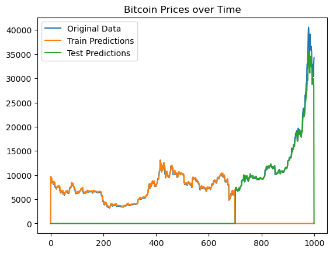

```python
train_predict_plot = np.empty_like(data)
train_predict_plot[:, :] = 0
train_predict_plot[look_back:len(y_pred_train)+look_back, :] = y_pred_train
test_predict_plot = np.empty_like(data)
test_predict_plot[:, :] = 0
test_predict_plot[len(y_pred_train)+(look_back*2)+1:len(data)-1, :] = y_pred_test

plt.plot(scaler.inverse_transform(scaled_data.copy()), label="Original Data")
plt.plot(train_predict_plot, label="Train Predictions")
plt.plot(test_predict_plot, label="Test Predictions")
plt.legend()
plt.title("Bitcoin Prices over Time")
plt.show()
```

By doubling the size of the network from our baseline 8 layer model, we have significantly increased the performance of the model. Now we will move onto LSTM models.

### LSTM Model 1

We will once again begin by halving the size of the network from 8 to 4 layers to observe how that affects the performance of the LSTM model.

```python
scaler = MinMaxScaler(feature_range=(0, 1))
scaled_data = scaler.fit_transform(data)

# Train test split of 70/30
train_size = int(len(scaled_data) * .7)
test_size = len(scaled_data) - train_size
train, test = scaled_data[0:train_size], scaled_data[train_size:]
print(len(train), len(test))

# Reshape dataset to X = t and y = t+1
# Look back 1 day
look_back = 1
X_train, y_train = create_dataset(train, look_back)
X_test, y_test = create_dataset(test, look_back)
print(X_train.shape, X_test.shape)

X_train = np.reshape(X_train, (X_train.shape[0], 1, X_train.shape[1]))
X_test = np.reshape(X_test, (X_test.shape[0], 1, X_test.shape[1]))
print(X_train.shape, X_test.shape)
```

```
700 300
(698, 1) (298, 1)
(698, 1, 1) (298, 1, 1)
```

```python
# LSTM Neural Network
model = Sequential()
model.add(LSTM(4, input_shape = (1, look_back)))
model.add(Dense(1))
model.compile(loss="mean_squared_error", optimizer="adam", metrics=["mean_squared_error"])
model.fit(X_train, y_train, epochs = 100, batch_size = 1, verbose = 2)
```

```
698/698 - 2s - 3ms/step - loss: 0.0039 - mean_squared_error: 0.0039
698/698 - 1s - 1ms/step - loss: 0.0017 - mean_squared_error: 0.0017
698/698 - 1s - 1ms/step - loss: 3.9759e-04 - mean_squared_error: 3.9759e-04
698/698 - 1s - 1ms/step - loss: 8.3900e-05 - mean_squared_error: 8.3900e-05
698/698 - 1s - 1ms/step - loss: 7.4118e-05 - mean_squared_error: 7.4118e-05
698/698 - 1s - 1ms/step - loss: 7.5283e-05 - mean_squared_error: 7.5283e-05
698/698 - 1s - 1ms/step - loss: 7.2178e-05 - mean_squared_error: 7.2178e-05
698/698 - 1s - 1ms/step - loss: 7.2409e-05 - mean_squared_error: 7.2409e-05
698/698 - 1s - 1ms/step - loss: 7.4978e-05 - mean_squared_error: 7.4978e-05
698/698 - 1s - 1ms/step - loss: 7.5832e-05 - mean_squared_error: 7.5832e-05
698/698 - 1s - 1ms/step - loss: 7.2859e-05 - mean_squared_error: 7.2859e-05
698/698 - 1s - 1ms/step - loss: 7.5541e-05 - mean_squared_error: 7.5541e-05
698/698 - 1s - 1ms/step - loss: 7.3746e-05 - mean_squared_error: 7.3746e-05
698/698 - 1s - 1ms/step - loss: 7.6968e-05 - mean_squared_error: 7.6968e-05
698/698 - 1s - 1ms/step - loss: 7.4186e-05 - mean_squared_error: 7.4186e-05
698/698 - 1s - 1ms/step - loss: 7.7256e-05 - mean_squared_error: 7.7256e-05
698/698 - 1s - 1ms/step - loss: 7.8843e-05 - mean_squared_error: 7.8843e-05
698/698 - 1s - 1ms/step - loss: 7.7108e-05 - mean_squared_error: 7.7108e-05
698/698 - 1s - 1ms/step - loss: 7.4244e-05 - mean_squared_error: 7.4244e-05
698/698 - 1s - 1ms/step - loss: 7.5989e-05 - mean_squared_error: 7.5989e-05
698/698 - 1s - 1ms/step - loss: 7.5123e-05 - mean_squared_error: 7.5123e-05
698/698 - 1s - 1ms/step - loss: 7.5564e-05 - mean_squared_error: 7.5564e-05
698/698 - 1s - 1ms/step - loss: 7.2824e-05 - mean_squared_error: 7.2824e-05
698/698 - 1s - 1ms/step - loss: 7.4486e-05 - mean_squared_error: 7.4486e-05
698/698 - 1s - 1ms/step - loss: 7.3898e-05 - mean_squared_error: 7.3898e-05
698/698 - 1s - 1ms/step - loss: 7.4428e-05 - mean_squared_error: 7.4428e-05
698/698 - 1s - 1ms/step - loss: 7.2739e-05 - mean_squared_error: 7.2739e-05
698/698 - 1s - 1ms/step - loss: 7.4472e-05 - mean_squared_error: 7.4472e-05
698/698 - 1s - 1ms/step - loss: 7.5357e-05 - mean_squared_error: 7.5357e-05
698/698 - 1s - 1ms/step - loss: 7.4021e-05 - mean_squared_error: 7.4021e-05
698/698 - 1s - 1ms/step - loss: 7.3951e-05 - mean_squared_error: 7.3951e-05
698/698 - 1s - 1ms/step - loss: 7.3030e-05 - mean_squared_error: 7.3030e-05
698/698 - 1s - 1ms/step - loss: 7.4610e-05 - mean_squared_error: 7.4610e-05
698/698 - 1s - 1ms/step - loss: 7.6023e-05 - mean_squared_error: 7.6023e-05
698/698 - 1s - 1ms/step - loss: 7.6761e-05 - mean_squared_error: 7.6761e-05
698/698 - 1s - 1ms/step - loss: 7.3683e-05 - mean_squared_error: 7.3683e-05
698/698 - 1s - 1ms/step - loss: 7.4248e-05 - mean_squared_error: 7.4248e-05
698/698 - 1s - 1ms/step - loss: 7.7445e-05 - mean_squared_error: 7.7445e-05
698/698 - 1s - 1ms/step - loss: 7.7183e-05 - mean_squared_error: 7.7183e-05
698/698 - 1s - 1ms/step - loss: 7.7537e-05 - mean_squared_error: 7.7537e-05
```

[output cut: 45 more lines]

```
698/698 - 1s - 1ms/step - loss: 7.2937e-05 - mean_squared_error: 7.2937e-05
698/698 - 1s - 1ms/step - loss: 7.0870e-05 - mean_squared_error: 7.0870e-05
698/698 - 1s - 1ms/step - loss: 7.1779e-05 - mean_squared_error: 7.1779e-05
698/698 - 1s - 1ms/step - loss: 7.4371e-05 - mean_squared_error: 7.4371e-05
698/698 - 1s - 1ms/step - loss: 7.3114e-05 - mean_squared_error: 7.3114e-05
698/698 - 1s - 1ms/step - loss: 7.1760e-05 - mean_squared_error: 7.1760e-05
698/698 - 1s - 1ms/step - loss: 7.3115e-05 - mean_squared_error: 7.3115e-05
698/698 - 1s - 1ms/step - loss: 7.3298e-05 - mean_squared_error: 7.3298e-05
698/698 - 1s - 1ms/step - loss: 7.5422e-05 - mean_squared_error: 7.5422e-05
698/698 - 1s - 1ms/step - loss: 7.1025e-05 - mean_squared_error: 7.1025e-05
698/698 - 1s - 1ms/step - loss: 7.4425e-05 - mean_squared_error: 7.4425e-05
698/698 - 1s - 1ms/step - loss: 7.3295e-05 - mean_squared_error: 7.3295e-05
698/698 - 1s - 1ms/step - loss: 7.2309e-05 - mean_squared_error: 7.2309e-05
698/698 - 1s - 1ms/step - loss: 7.3309e-05 - mean_squared_error: 7.3309e-05
698/698 - 1s - 1ms/step - loss: 7.3025e-05 - mean_squared_error: 7.3025e-05
```

```
<keras.src.callbacks.history.History at 0x1776db890>
```

```python
# Make predictions
y_pred_train = model.predict(X_train)
y_pred_test = model.predict(X_test)
# Unscale predictions
y_pred_train = scaler.inverse_transform(y_pred_train)
y_pred_test = scaler.inverse_transform(y_pred_test)
y_train = scaler.inverse_transform([y_train])
y_test = scaler.inverse_transform([y_test])
# Calculate RMSE
train_score = np.sqrt(mean_squared_error(y_train[0], y_pred_train[:,0]))
test_score = np.sqrt(mean_squared_error(y_test[0], y_pred_test[:, 0]))
print(f"Train RMSE: {train_score}")
print(f"Test RMSE: {test_score}")
```

```
22/22 ━━━━━━━━━━━━━━━━━━━━ 0s 8ms/step
10/10 ━━━━━━━━━━━━━━━━━━━━ 0s 1ms/step
Train RMSE: 303.1588731787425
Test RMSE: 3070.206264761673
```

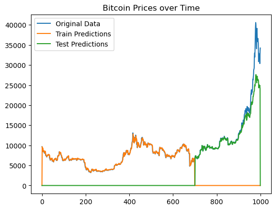

```python
train_predict_plot = np.empty_like(data)
train_predict_plot[:, :] = 0
train_predict_plot[look_back:len(y_pred_train)+look_back, :] = y_pred_train
test_predict_plot = np.empty_like(data)
test_predict_plot[:, :] = 0
test_predict_plot[len(y_pred_train)+(look_back*2)+1:len(data)-1, :] = y_pred_test

plt.plot(scaler.inverse_transform(scaled_data.copy()), label="Original Data")
plt.plot(train_predict_plot, label="Train Predictions")
plt.plot(test_predict_plot, label="Test Predictions")
plt.legend()
plt.title("Bitcoin Prices over Time")
plt.show()
```

Unsurprisingly, halving the size of the network has significantly reduced its ability to accurately predict the price of bitcoin. It appears that the number of layers has an even larger affect on LSTM than on Simple RNN.

### LSTM Model 2

For our last model, we will double the number of layers from 8 to 16 to see if we can increase the performance of the LSTM model.

```python
scaler = MinMaxScaler(feature_range=(0, 1))
scaled_data = scaler.fit_transform(data)

# Train test split of 70/30
train_size = int(len(scaled_data) * .7)
test_size = len(scaled_data) - train_size
train, test = scaled_data[0:train_size], scaled_data[train_size:]
print(len(train), len(test))

# Reshape dataset to X = t and y = t+1
# Look back 1 day
look_back = 1
X_train, y_train = create_dataset(train, look_back)
X_test, y_test = create_dataset(test, look_back)
print(X_train.shape, X_test.shape)

X_train = np.reshape(X_train, (X_train.shape[0], 1, X_train.shape[1]))
X_test = np.reshape(X_test, (X_test.shape[0], 1, X_test.shape[1]))
print(X_train.shape, X_test.shape)
```

```
700 300
(698, 1) (298, 1)
(698, 1, 1) (298, 1, 1)
```

```python
# LSTM Neural Network
model = Sequential()
model.add(LSTM(16, input_shape = (1, look_back)))
model.add(Dense(1))
model.compile(loss="mean_squared_error", optimizer="adam", metrics=["mean_squared_error"])
model.fit(X_train, y_train, epochs = 100, batch_size = 1, verbose = 2)
```

```
698/698 - 2s - 3ms/step - loss: 0.0030 - mean_squared_error: 0.0030
698/698 - 1s - 1ms/step - loss: 4.1997e-04 - mean_squared_error: 4.1997e-04
698/698 - 1s - 1ms/step - loss: 7.6726e-05 - mean_squared_error: 7.6726e-05
698/698 - 1s - 1ms/step - loss: 7.9583e-05 - mean_squared_error: 7.9583e-05
698/698 - 1s - 1ms/step - loss: 7.8001e-05 - mean_squared_error: 7.8001e-05
698/698 - 1s - 1ms/step - loss: 7.8255e-05 - mean_squared_error: 7.8255e-05
698/698 - 1s - 1ms/step - loss: 8.0661e-05 - mean_squared_error: 8.0661e-05
698/698 - 1s - 1ms/step - loss: 8.6533e-05 - mean_squared_error: 8.6533e-05
698/698 - 1s - 1ms/step - loss: 8.1072e-05 - mean_squared_error: 8.1072e-05
698/698 - 1s - 1ms/step - loss: 8.2625e-05 - mean_squared_error: 8.2625e-05
698/698 - 1s - 1ms/step - loss: 7.9403e-05 - mean_squared_error: 7.9403e-05
698/698 - 1s - 1ms/step - loss: 8.0324e-05 - mean_squared_error: 8.0324e-05
698/698 - 1s - 1ms/step - loss: 8.0386e-05 - mean_squared_error: 8.0386e-05
698/698 - 1s - 1ms/step - loss: 7.9931e-05 - mean_squared_error: 7.9931e-05
698/698 - 1s - 1ms/step - loss: 7.9202e-05 - mean_squared_error: 7.9202e-05
698/698 - 1s - 1ms/step - loss: 8.4275e-05 - mean_squared_error: 8.4275e-05
698/698 - 1s - 1ms/step - loss: 7.7310e-05 - mean_squared_error: 7.7310e-05
698/698 - 1s - 1ms/step - loss: 7.5997e-05 - mean_squared_error: 7.5997e-05
698/698 - 1s - 1ms/step - loss: 8.0132e-05 - mean_squared_error: 8.0132e-05
698/698 - 1s - 1ms/step - loss: 7.8712e-05 - mean_squared_error: 7.8712e-05
698/698 - 1s - 1ms/step - loss: 7.9480e-05 - mean_squared_error: 7.9480e-05
698/698 - 1s - 1ms/step - loss: 8.0647e-05 - mean_squared_error: 8.0647e-05
698/698 - 1s - 1ms/step - loss: 7.8586e-05 - mean_squared_error: 7.8586e-05
698/698 - 1s - 1ms/step - loss: 7.9787e-05 - mean_squared_error: 7.9787e-05
698/698 - 1s - 1ms/step - loss: 8.1869e-05 - mean_squared_error: 8.1869e-05
698/698 - 1s - 1ms/step - loss: 7.8180e-05 - mean_squared_error: 7.8180e-05
698/698 - 1s - 1ms/step - loss: 7.6578e-05 - mean_squared_error: 7.6578e-05
698/698 - 1s - 1ms/step - loss: 8.2893e-05 - mean_squared_error: 8.2893e-05
698/698 - 1s - 1ms/step - loss: 7.8161e-05 - mean_squared_error: 7.8161e-05
698/698 - 1s - 1ms/step - loss: 8.2322e-05 - mean_squared_error: 8.2322e-05
698/698 - 1s - 1ms/step - loss: 8.2342e-05 - mean_squared_error: 8.2342e-05
698/698 - 1s - 1ms/step - loss: 8.0402e-05 - mean_squared_error: 8.0402e-05
698/698 - 1s - 1ms/step - loss: 8.2132e-05 - mean_squared_error: 8.2132e-05
698/698 - 1s - 1ms/step - loss: 7.6570e-05 - mean_squared_error: 7.6570e-05
698/698 - 1s - 1ms/step - loss: 7.7036e-05 - mean_squared_error: 7.7036e-05
698/698 - 1s - 1ms/step - loss: 7.3529e-05 - mean_squared_error: 7.3529e-05
698/698 - 1s - 1ms/step - loss: 7.7291e-05 - mean_squared_error: 7.7291e-05
698/698 - 1s - 1ms/step - loss: 7.5820e-05 - mean_squared_error: 7.5820e-05
698/698 - 1s - 1ms/step - loss: 7.7283e-05 - mean_squared_error: 7.7283e-05
698/698 - 1s - 1ms/step - loss: 8.0330e-05 - mean_squared_error: 8.0330e-05
```

[output cut: 45 more lines]

```
698/698 - 1s - 1ms/step - loss: 7.9595e-05 - mean_squared_error: 7.9595e-05
698/698 - 1s - 1ms/step - loss: 7.6284e-05 - mean_squared_error: 7.6284e-05
698/698 - 1s - 1ms/step - loss: 7.5793e-05 - mean_squared_error: 7.5793e-05
698/698 - 1s - 1ms/step - loss: 7.3250e-05 - mean_squared_error: 7.3250e-05
698/698 - 1s - 1ms/step - loss: 7.6875e-05 - mean_squared_error: 7.6875e-05
698/698 - 1s - 1ms/step - loss: 7.7033e-05 - mean_squared_error: 7.7033e-05
698/698 - 1s - 1ms/step - loss: 7.9147e-05 - mean_squared_error: 7.9147e-05
698/698 - 1s - 1ms/step - loss: 7.5875e-05 - mean_squared_error: 7.5875e-05
698/698 - 1s - 1ms/step - loss: 7.3684e-05 - mean_squared_error: 7.3684e-05
698/698 - 1s - 1ms/step - loss: 7.6394e-05 - mean_squared_error: 7.6394e-05
698/698 - 1s - 1ms/step - loss: 7.6255e-05 - mean_squared_error: 7.6255e-05
698/698 - 1s - 1ms/step - loss: 7.4535e-05 - mean_squared_error: 7.4535e-05
698/698 - 1s - 1ms/step - loss: 7.2476e-05 - mean_squared_error: 7.2476e-05
698/698 - 1s - 1ms/step - loss: 7.7791e-05 - mean_squared_error: 7.7791e-05
698/698 - 1s - 1ms/step - loss: 7.3673e-05 - mean_squared_error: 7.3673e-05
```

```
<keras.src.callbacks.history.History at 0x177abc8d0>
```

```python
# Make predictions
y_pred_train = model.predict(X_train)
y_pred_test = model.predict(X_test)
# Unscale predictions
y_pred_train = scaler.inverse_transform(y_pred_train)
y_pred_test = scaler.inverse_transform(y_pred_test)
y_train = scaler.inverse_transform([y_train])
y_test = scaler.inverse_transform([y_test])
# Calculate RMSE
train_score = np.sqrt(mean_squared_error(y_train[0], y_pred_train[:,0]))
test_score = np.sqrt(mean_squared_error(y_test[0], y_pred_test[:, 0]))
print(f"Train RMSE: {train_score}")
print(f"Test RMSE: {test_score}")
```

```
22/22 ━━━━━━━━━━━━━━━━━━━━ 0s 8ms/step
10/10 ━━━━━━━━━━━━━━━━━━━━ 0s 1ms/step
Train RMSE: 307.7479428176186
Test RMSE: 1808.9961923759352
```

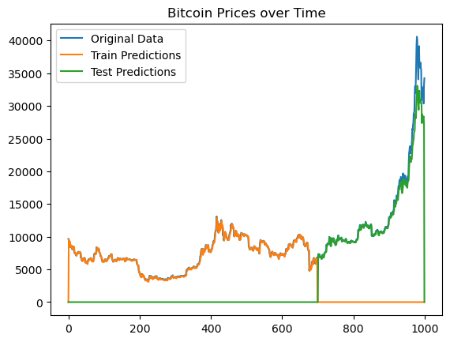

```python
train_predict_plot = np.empty_like(data)
train_predict_plot[:, :] = 0
train_predict_plot[look_back:len(y_pred_train)+look_back, :] = y_pred_train
test_predict_plot = np.empty_like(data)
test_predict_plot[:, :] = 0
test_predict_plot[len(y_pred_train)+(look_back*2)+1:len(data)-1, :] = y_pred_test

plt.plot(scaler.inverse_transform(scaled_data.copy()), label="Original Data")
plt.plot(train_predict_plot, label="Train Predictions")
plt.plot(test_predict_plot, label="Test Predictions")
plt.legend()
plt.title("Bitcoin Prices over Time")
plt.show()
```

While we have increased the performance of the model, the Simple RNN model still performed better at predicting the price of Bitcoin.